# Coursework Report

*N* removed NAs: 2

*N* removed typo: 1

*N* removed <18: 14

*N* total clean: 133

| Group | *N* | *M*<sub>age</sub> | *M*<sub>rating</sub> |
| --- | --- | --- | --- |
| Control | 60 | 20.82 | 6.42 |
| Experim | 73 | 21.11 | 5.64 |

**Main analysis results**

*t*(131) = 5.8, *p* < .001

[interactive chart not shown]

[figure not shown]

[interactive chart not shown]

# Coursework Report

Analysing Data, Spring 2020

# Methods

## Participants

Originally, 150 individuals participated in this experiment. After data checking and cleaning were carried out however, 17 of these original participants were removed. There were various reasons as to why these participants were removed. The first reason was that no age data was provided for two of the original participants. The rest of their data was therefore removed and we were down to 148 participants. Next, participants with unethical ages were removed from the study. This consisted of 14 participants who were under the age of 18 and, for ethical reasons, could not be involved in the study. Their data was also therefore removed. A final participant was removed as their age was unrealistic – the age data for this participant had them down as 200 years old, which is seemingly impossible, so this participant’s data was also removed from the study. After the data of these 17 participants had been removed from the data set, the mean, standard deviation and minimum and maximum ages of the participants were calculated and are displayed in ‘Figure 1’ below. The range of the participants’ ages was 9. The final number of participants that were included in the study was 133. Their data is displayed below in ‘Figure 2’ – a descriptives table of age by experimental condition.

Figure 1. *Summary table of participants’ ages*

| Mean | SD | Minimum | Maximum |
| --- | --- | --- | --- |
| 20.98 | 1.98 | 18 | 27 |

Figure 2. *Descriptives table of age by experimental condition*

| Condition | *N* | % | Mean<sub>age</sub> | SD<sub>age</sub> |
| --- | --- | --- | --- | --- |
| control | 60 | 45.11 | 20.82 | 1.94 |
| experimental | 73 | 54.89 | 21.11 | 2.01 |

## Design

The main research question being explored in this experiment is whether or not colour influences attractiveness, more specifically, whether the colour red increases women’s attraction to men. The variables in this experiment were colour and attractiveness. The independent variable (the variable that is manipulated by the researcher) in this study was colour, namely the colour of the frame surrounding the picture of the man that the participants were asked to rate. In the study, the participants in the control condition saw the picture of the man in a white frame while the participants in the experimental condition saw the picture of the man in a red frame. This variable was a factor. The dependent variable in this study (the variable that is measured) was attractiveness, more specifically, the average of three ratings made by the participants. The individuals were asked to score the picture of the man on a scale of 1-9 in regards to three questions. These questions were ‘how attractive do you think this person is?’, ‘how pleasant is this person to look at?’ and finally ‘if I were to meet this person in real life, would I think he is attractive?’. Each participant gave a score from 1-9 for each question. These three answers were then averaged to get a composite score for each participant. In the study, attractiveness was a rating. The operationalised hypothesis for this study stated that ratings of attractiveness of a moderately attractive man will differ depending on the colour of the frame that the picture is in. A statistical *t*-test will be used to analyse the results.

# Results

The results generated from this research are shown in the graph below (Figure 3). It can be seen from the results displayed in this graph that there was a higher mean for the participants in the control group (who were shown the photograph in the white frame) when compared to the participants in the experimental condition (who were shown the photograph in the red frame).

Figure 3. *Graph showing mean composite score by condition*

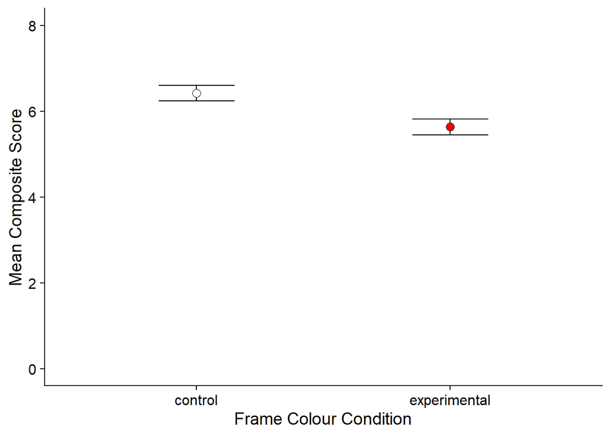

A *t*-test was then carried out in order to further analyse the results from the data. In order to carry out the t-test, a composite score was calculated from an average of the three ratings for each participant. Therefore, each participant had a composite score. These scores were then used in order to carry out the *t*-test.

# Discussion

The original hypothesis of this study stated that attractiveness ratings would be influenced by colour and that the colour red would increase attractiveness ratings given by the participants. These results have shown however, that this is not the case. From the graph shown above and the results of the *t*-test that have been explained, we can see that, in fact, the colour red reduced ratings of attractiveness (the opposite of that was expected). The participants in the experimental who saw the picture of a man in the red frame gave a mean composite rating of 5.64. The participants in the control condition who saw the picture of a man in the white frame gave a mean composite rating of 6.42. These results are not in line with the original hypothesis as the mean composite rating of the experimental condition is actually lower, not higher, than the mean composite rating of the control condition. The hypothesis given at the beginning therefore must be rejected. The null hypothesis is also rejected however because there is a difference in the way colour affects attractiveness ratings (the null hypothesis would have stated that there would be no difference in attractiveness ratings based on colour). The *t*-test that was carried out suggested that the difference between the mean ratings given was significant. It can be concluded from this therefore that colour does have an effect on attractiveness ratings, however it is not the colour red that increases these ratings.

This study was influenced by a study carried out in 2010 by Elliot and colleagues. This original study had the same general research question regarding the colour red influencing attractiveness ratings among women. The results from the original experiment were also analysed by an independent t-test and similarly found that there was a significant colour effect. However, it was found in the Elliot et al. study that the colour red increased attractiveness ratings. It was shown that participants who were part of the experimental condition (also known as the red condition) did in fact rate the picture of the man as more attractive than the participants in the control condition (also known as the white condition) did. The results from this original study therefore support the hypothesis and implied that the colour red does in fact influence ratings of attractiveness.

The results from our study are quite the opposite of the results from the original study. In fact, our results are similar to those found in a more recent study by Peperkoorn and colleagues (2016). The results from this study show that there was a higher rating for attractiveness of the picture in the white condition than there was of the picture in the red condition. These findings were not in line with the hypothesis for this study which predicted that the picture in red would be found to be the most attractive. It is interesting to see that other studies with the same general research question have produced similar results to that of our own. The fact that the results generated by our data are similar to the Peperkoorn et al. study but are the complete opposite of the Elliot et al. study may suggest a few things. It could imply that attraction is subjective and that the different pictures used in the three different studies were perceived differently by all of the different participants. It is also clear in the 2016 study that the participants were men looking at a picture of a woman. In the 2010 study the participants were women looking at men. In our study, there is no data relating to the gender of the participants. It may be therefore that there an implication of using participants of a specific gender for studies like these. It may be that men and women view gender in different ways and with different factors attached which are deemed as important when it comes to rating attraction.

One clear limitation of this research is that the two groups of participants looked at different pictures. The picture presented to the control group was of a different man than in the picture presented to the experimental group. This may be the factor of the experiment that explains why the control group gave a higher rating of attractiveness. It may actually be that researchers were not measuring the effect of the different coloured frame. It is possible that the man in the picture presented to the white group was in fact more attractive than the man in the picture presented to the red group. This seems to be a major limitation to this study. In future research carried out on this topic, it should be ensured that the pictures of the men are either of very very similar attraction or that the same picture is presented to both groups. The latter suggestion would be preferred as it ensures that the researchers will definitely be measuring the effect of the coloured frame on ratings of attraction.

A further possible limitation with this study concerns the generation of the composite score for each participant. During the data analysis process and in order to make the graph which displayed our results clearly, a composite score was made for each participant by averaging their scores for the three questions they were asked when looking at the picture of the man. Looking at the participants’ scores for each item and then looking at their composite score makes for some interesting data. While the majority of the participants had similar scores for each question (for example, 7,6,7 or 5,5,5) some participants had scores which were not very similar. For example, one participants scores were 6,3,5 while another had scores of 2,5,7. These scores may have had quite an impact when it came to generating the composite scores, resulting in them being lower than they may have otherwise been. This may have gone on to have an effect on the mean composite scores which were used not only to generate the graph, but also in the *t*-test to create *t* values which were used for analysis of the results. The reasons for these outlying scores may be down to interpretation of the question by individuals or a misunderstanding of the question. It may also be that participants were trying to vary their answers in order to try and please the researcher. Another possibility is that the participants got confused by the similarity of the three questions and so as a results gave varied scores. Future studies may want to ensure that the questions asked to participants are different enough so that the participants don’t confuse the three questions and attempt to give different scores as answers in order to please the researchers. It may even be that researchers carrying out similar studies in the future ask the participants only 2 questions for them to rate the photograph against in order to minimise confusion.

# Conclusion

In conclusion, the main research question asked whether or not there was a connection between the colour red and an increase in attraction. Our results have shown that although there is a relationship between colour and attractiveness, it is not one which was first expected. It was found in this study that the white group rated their picture as more attractive than the red group did (they had a higher mean composite score). The results have been compared to similar previous studies. Limitations of this study including outlying scores and the use of two pictures have been addressed and suggestions for further research have been outlined.

*** WORD LIMIT REACHED ***

# References

Elliot, Andrew J., Daniela Niesta Kayser, Tobias Greitemeyer, Stephanie Lichtenfeld, Richard H. Gramzow, Markus A. Maier, and Huijun Liu. ‘Red, Rank, and Romance in Women Viewing Men.’ Journal of Experimental Psychology: General 139, no. 3 (2010): 399–417. https://doi.org/10.1037/a0019689.

Peperkoorn, Leonard S., S. Craig Roberts, and Thomas V. Pollet. ‘Revisiting the Red Effect on Attractiveness and Sexual Receptivity: No Effect of the Color Red on Human Mate Preferences’. Evolutionary Psychology 14, no. 4 (17 October 2016): 147470491667384. https://doi.org/10.1177/1474704916673841.